# Java-Session-01

Infosys - Java Programming - Session -01

**What is Programming ?**  
Structured set of instructions which is used solve a problem with the help of a computer

**Psuedo Codes, Algorithms & FLowcharts** are just the logics and can be implemented in any programming language if we just look for the syntax|

### Java

Logics are applied on the Data . Data Storage is very important.

1. How to store the data
2. How to perform operations on Data
3. How to write the statements

For reference Lex id 56623 *Course:: Programming using Java*

*Types of data*

### Lesson 1

Terms to know in Java

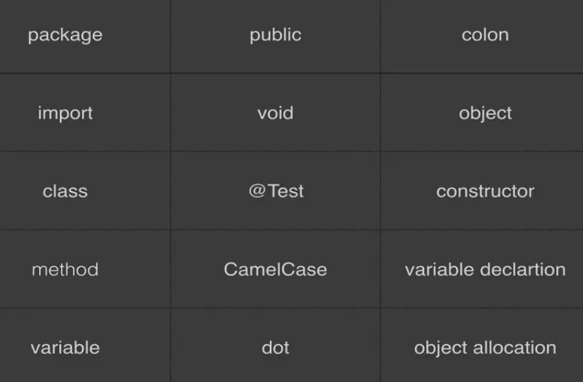

*Package*  
`package com.marcusbiel.javacourse.lesson1`

*import*

`import PackageDeclaration`  
`import com.marcusbiel.lesson1.garage`  
`import static org.junit.Assert*`

*class*  
Programmers decide on the names that are actual objects that are related to business to ease up the understanding of the project.

class Car{ }

Class id the Blueprint

*method*  
(a class may consist of one or more methods)  
By convention name of the method should be a word that best describes the purpose of the method. Ex: `double(2)=4`  
Methods can be operable on names , numbers anything  
Methods can internally call another method and the hierarchy follows. Readibility of code is very important so keeping methods as short as possible with 20 lines as maximum

```
drive(speed){
}
```

to use as few method parametres as possible with 5 max

*variable*  
can be of different data types.

Types of variables

- instance variable
- static variable
- local variable
- parameter
- argument

*Public* access modifier

```
public class Car{
    public void drive(Speed){
    }
}
```

*void*  
(every method you have to define a return value even if you dont want to return any value at all) In that case we can use void

*@Test* we indicate that given method will be used as a test

*CamelCase*  
`camel_hump` in java camel case is used to club the words

*dot*  
(dot is used to call the method drive on object Car) `car.drive()`

*colon* `;` is used to indicate the end of statements in java

```
@Test
public void shouldDrive(){
    car.drive(100);
}
```

*object oriented language*  
everything in java is focused around objects.

```
class Car(age,maxSpeed)

objects
myOldCar(10 years old, max speed 120)
myPorsche(1 year old, max speed 320)
mumsCar(3 years old, max speed 180)
```

*constructor*  
This is a specific method when called on a class will create a specific object for us.

new Car(10,120);

*variable declaration*  
we need to define variable before hand before using it

`Car myPorsche;`  
I created a new variable of type Car with name myPorsche

*object allocation*  
variable declaration object creation and allocation can be done in one single line  
`Car myPorsche = new Car(1,320)`

### Lesson 2

```java
public class Person {

    private Name personName;

    public String helloWorld(){
        return "Hello World";
    }
    public Name name(){
        return personName;
    }
}
```

```
|   public class Person {
|       private Name personName;
|       public String helloWorld(){
|           return "Hello World";
|       }
|       public Name name(){
|           return personName;
|       }
|   }
Unresolved dependencies:
   - class Name
```

```java
package com.marcusbiel.javacourse.lesson2;
import com.marcusbiel.javacourse.lesson3.Name;

import org.junit.Test;
import static org.junit.Assert.assertEquals;
public class PersonTest {
    @Test
    public void shouldReturnHelloWorld(){

        Person marcus = new Person();
        assertEquals("Hello World")
    }
}
public class PersonTest {
    @Test
    public void shouldReturnHelloWorld(){

        Person marcus = new Person();
        assertEquals("Hello World");
    }
}
```

```
|   package com.marcusbiel.javacourse.lesson2;
illegal start of expression
```